# HW2-explore and wrangle

2016-10-05

## Setup

```r
library(devtools)
library(rcfss)
library(tidyverse)
library(stringr)
library(scales)
```

## Part 1: Exploring clean data

Using your knowledge of dplyr and ggplot2, use summary statistics and graphs to answer the following questions: 1. In what month do the most gun deaths occur? 2. What is the most common intent in gun deaths? Do most people killed by guns die in suicides, homicides, or accidental shootings? 3. What is the average age of females killed by guns? 4. How many white males with at least a high school education were killed by guns in 2012? 5. Which season of the year has the most gun deaths? Assume that Winter = January-March Spring = April-June Summer = July-September Fall = October-December 6. What is the relationship between race and intent? For example, are whites who are killed by guns more likely to die because of suicide or homicide? How does this compare to blacks and hispanics?

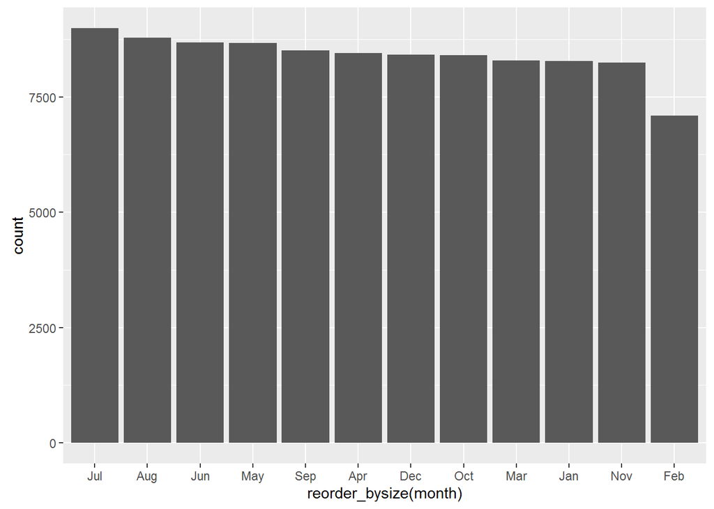

```r
data("gun_deaths")

reorder_bysize <- function(x) {
  factor(x, levels = names(sort(table(x), decreasing = TRUE)))
}

#1
gdeaths_tidy <- gun_deaths %>%
  mutate(month = as.factor(month.abb[month]))

ggplot(gdeaths_tidy, aes(reorder_bysize(month))) +
  geom_bar()
```

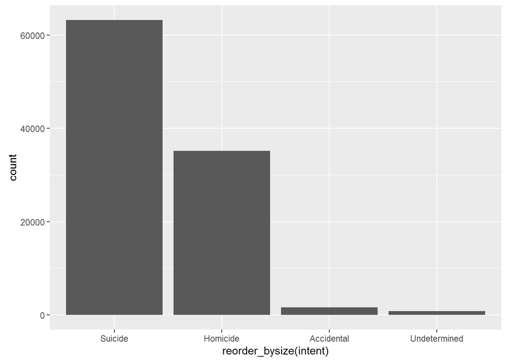

```r
#2
gdeaths_tidy <- gun_deaths %>%
  mutate(intent = as.factor(intent))

ggplot(gdeaths_tidy[!is.na(gdeaths_tidy$intent), ], aes(reorder_bysize(intent))) +
  geom_bar()
```

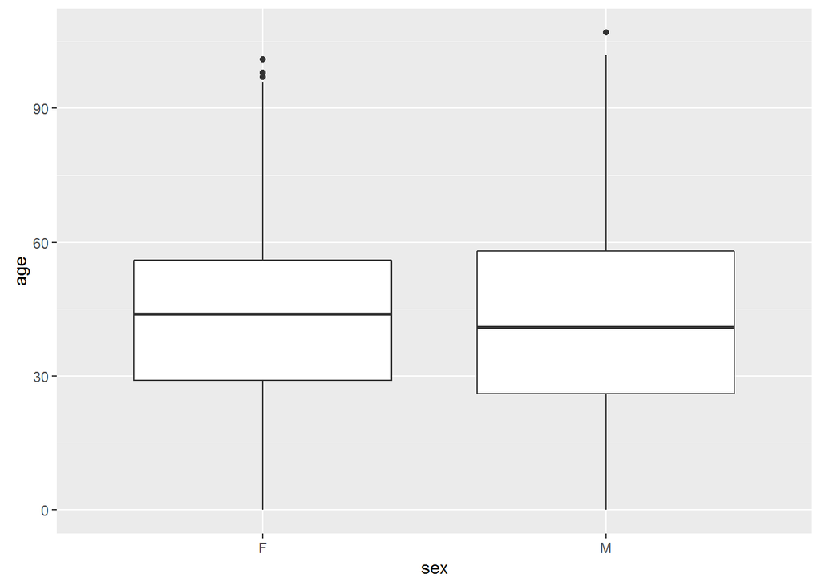

```r
#3
gdeaths_tidy <- gun_deaths %>%
  group_by(sex)

ggplot(gdeaths_tidy, aes(sex, age)) +
  geom_boxplot()
```

```r
summarize(gdeaths_tidy, avgAge = mean(age, na.rm = TRUE))
```

```
## # A tibble: 2 × 2
##     sex   avgAge
##   <chr>    <dbl>
## 1     F 43.69507
## 2     M 43.88480
```

```r
#4
gdeaths_tidy <- gun_deaths %>%
  filter(education != "Less than HS", year == 2012, sex == "M", race == "White")

summarize(gdeaths_tidy, n = n())
```

```
## # A tibble: 1 × 1
##       n
##   <int>
## 1 15199
```

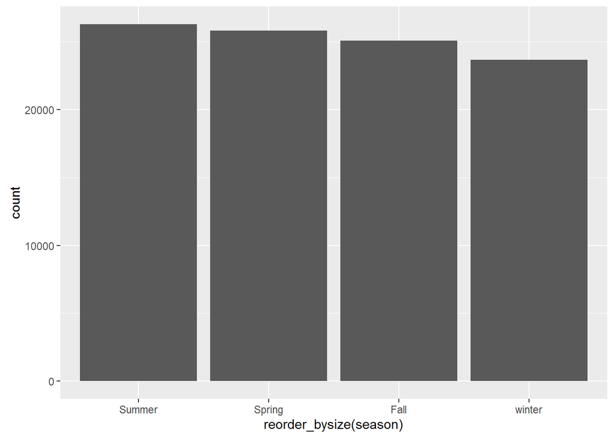

```r
#the answer from prof is without the criterion of white

#5
gdeaths_tidy <- gun_deaths %>%
  mutate(season = month)

gdeaths_tidy$season[gdeaths_tidy$season %in% c(1, 2, 3)] <- "winter"
gdeaths_tidy$season[gdeaths_tidy$season %in% c(4, 5, 6)] <- "Spring"
gdeaths_tidy$season[gdeaths_tidy$season %in% c(7, 8, 9)] <- "Summer"
gdeaths_tidy$season[gdeaths_tidy$season %in% c(10, 11, 12)] <- "Fall"

ggplot(gdeaths_tidy, aes(reorder_bysize(season))) +
  geom_bar()
```

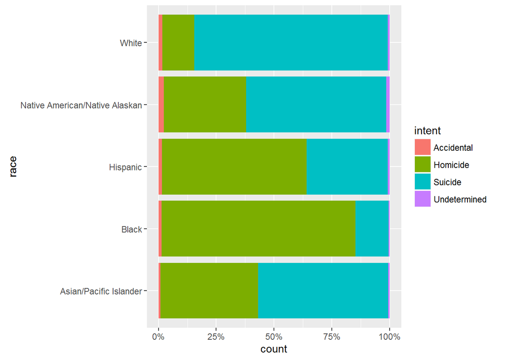

```r
#6
gdeaths_tidy <- gun_deaths

ggplot(gdeaths_tidy, aes(race, fill = intent)) +
  geom_bar(position = "fill") +
  coord_flip() +
  scale_y_continuous(labels = percent_format())
```

## Part 2: Tidying messy data

Tidy this data frame so that it adheres to the tidy data principles:

```r
data("dadmom")
dad <- dadmom %>%
  transmute(famid, name = named, inc = incd, type = "dad")
mom <- dadmom %>%
  transmute(famid, name = namem, inc = incm, type = "mom")

dadmom_tidy <- bind_rows(dad, mom)
dadmom_tidy
```

```
## # A tibble: 6 × 4
##   famid  name   inc  type
##   <dbl> <chr> <dbl> <chr>
## 1     1  Bill 30000   dad
## 2     2   Art 22000   dad
## 3     3  Paul 25000   dad
## 4     1  Bess 15000   mom
## 5     2   Amy 18000   mom
## 6     3   Pat 50000   mom
```

## Part 3: Wrangling and exploring messy(ish) data

There are several ID variables which are useful for other types of research: for our purposes, the only ID variable you need to concern yourself with is caseIssuesId. Variables you will want to familiarize yourself with include: term, justice, justiceName, decisionDirection, majVotes, minVotes, majority, and chief. Pay careful attention in the documentation to how these variables are coded.

Once joined, use your data wrangling and exploratory data analysis skills to answer the following questions: 1. What percentage of cases in each term are decided by a one-vote margin (i.e. 5-4, 4-3, etc.) 2. In each term he served on the Court, in what percentage of cases was Justice Antonin Scalia in the majority? 3A. Advanced challenge: Create a graph similar to above that compares the percentage for all cases versus non-unanimous cases (i.e. there was at least one dissenting vote) 4. In each term, what percentage of cases were decided in the conservative direction? 5A. Advanced challenge: The Chief Justice is frequently seen as capable of influencing the ideological direction of the Court. Create a graph similar to the one above that also incorporates information on who was the Chief Justice during the term.

Terms run from October through June, so the 2015 term contains cases decided from October 2015 - June 2016

```r
jcitation_legacy <- read_csv("data/SCDB_Legacy_03_justiceCentered_Citation.csv") %>%
  mutate(docket = as.integer(docket), adminAction = as.integer(adminAction), adminActionState = as.integer(adminActionState))
jcitation_modern <- read_csv("data/SCDB_2016_01_justiceCentered_Citation.csv")
jcitation_all <- bind_rows (jcitation_legacy, jcitation_modern) %>%
  transmute(caseIssuesId, term, justice, justiceName, decisionDirection, majVotes, minVotes, majority, chief)

jcitation_all
```

```
## # A tibble: 250,448 × 9
##      caseIssuesId  term justice justiceName decisionDirection majVotes
##             <chr> <int>   <int>       <chr>             <int>    <int>
## 1  1791-001-01-01  1791       1        JJay                 1        5
## 2  1791-001-01-01  1791       3    WCushing                 1        5
## 3  1791-001-01-01  1791       4     JWilson                 1        5
## 4  1791-001-01-01  1791       5      JBlair                 1        5
## 5  1791-001-01-01  1791       6    JIredell                 1        5
## 6  1791-002-01-01  1791       1        JJay                 2        5
## 7  1791-002-01-01  1791       3    WCushing                 2        5
## 8  1791-002-01-01  1791       4     JWilson                 2        5
## 9  1791-002-01-01  1791       5      JBlair                 2        5
## 10 1791-002-01-01  1791       6    JIredell                 2        5
## # ... with 250,438 more rows, and 3 more variables: minVotes <int>,
## #   majority <int>, chief <chr>
```

```r
#1
jcitation_ref <- jcitation_all %>%
  distinct(caseIssuesId, .keep_all = TRUE) %>%
  group_by(term) %>%
  summarize(totalNumber = n())

jcitation_ref
```

```
## # A tibble: 223 × 2
##     term totalNumber
##    <int>       <int>
## 1   1791           2
## 2   1792           4
## 3   1793           3
## 4   1794           2
## 5   1795           6
## 6   1796          16
## 7   1797           8
## 8   1798           6
## 9   1799           7
## 10  1800           9
## # ... with 213 more rows
```

```r
jcitation_tidy <- jcitation_all %>%
  distinct(caseIssuesId, .keep_all = TRUE) %>%
  mutate(difference = majVotes - minVotes) %>%
  group_by(term, difference) %>%
  summarize(number = n()) %>%
  filter(difference == 1) %>%
  left_join(jcitation_ref, by = "term") %>%
  mutate(percentage = number / totalNumber)

jcitation_tidy
```

```
## Source: local data frame [155 x 5]
## Groups: term [155]
##
##     term difference number totalNumber percentage
##    <int>      <int>  <int>       <int>      <dbl>
## 1   1794          1      1           2 0.50000000
## 2   1816          1      1          42 0.02380952
## 3   1818          1      1          38 0.02631579
## 4   1822          1      1          32 0.03125000
## 5   1827          1      2          47 0.04255319
## 6   1830          1      1          57 0.01754386
## 7   1837          1      1          20 0.05000000
## 8   1845          1      2          52 0.03846154
## 9   1849          1      2          42 0.04761905
## 10  1850          1      6         168 0.03571429
## # ... with 145 more rows
```

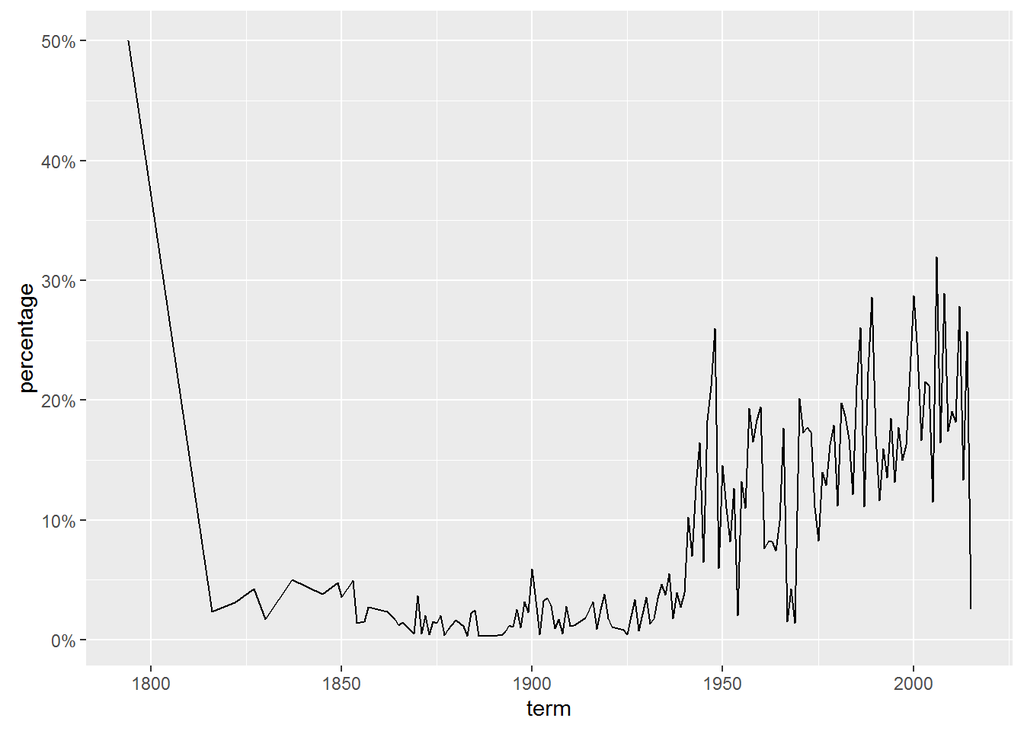

```r
ggplot(jcitation_tidy, aes(term, percentage)) +
  geom_line() +
  scale_y_continuous(labels = percent_format())
```

```r
#2
jcitation_ref <- jcitation_all %>%
  filter(justiceName == "AScalia") %>%
  group_by(term) %>%
  summarize(totalNumber = n())

jcitation_tidy <- jcitation_all %>%
  filter(justiceName == "AScalia", majority == 2) %>%
  group_by(term) %>%
  summarize(number = n()) %>%
  left_join(jcitation_ref, by = "term") %>%
  mutate(percentage = number / totalNumber)

jcitation_tidy
```

```
## # A tibble: 30 × 4
##     term number totalNumber percentage
##    <int>  <int>       <int>      <dbl>
## 1   1986    130         161  0.8074534
## 2   1987    122         153  0.7973856
## 3   1988    132         152  0.8684211
## 4   1989    116         140  0.8285714
## 5   1990    106         129  0.8217054
## 6   1991     96         120  0.8000000
## 7   1992    111         119  0.9327731
## 8   1993     84          96  0.8750000
## 9   1994     76          92  0.8260870
## 10  1995     74          91  0.8131868
## # ... with 20 more rows
```

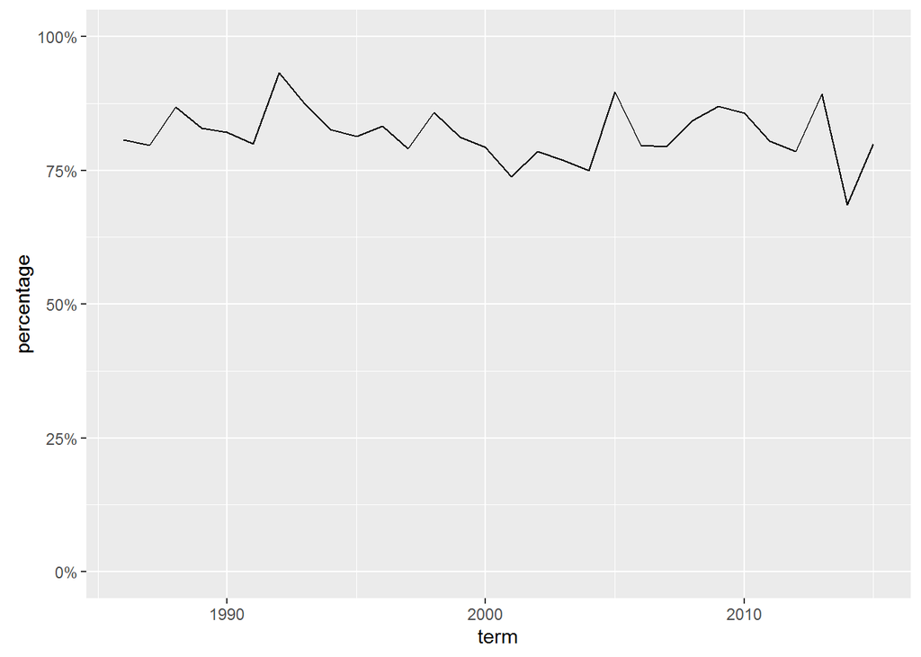

```r
ggplot(jcitation_tidy, aes(term, percentage)) +
  geom_line() +
  scale_y_continuous(limits = c(0, 1), labels = percent_format())
```

```r
#3A
jcitation_ref <- jcitation_all %>%
  filter(justiceName == "AScalia") %>%
  mutate(ifUnanimous = minVotes)

jcitation_ref$ifUnanimous[jcitation_ref$ifUnanimous > 0] <- "nonUnanimous"
jcitation_ref$ifUnanimous[jcitation_ref$ifUnanimous == 0] <- "unanimous"

jcitation_ref <- jcitation_ref %>%
  group_by(term, ifUnanimous) %>%
  summarize(totalNumber = n()) %>%
  spread(key = ifUnanimous, value = totalNumber) %>%
  mutate(totalNumber = nonUnanimous + unanimous)

jcitation_ref
```

```
## Source: local data frame [30 x 4]
## Groups: term [30]
##
##     term nonUnanimous unanimous totalNumber
##    <int>        <int>     <int>       <int>
## 1   1986          108        53         161
## 2   1987           85        68         153
## 3   1988           89        63         152
## 4   1989           92        48         140
## 5   1990           74        55         129
## 6   1991           73        47         120
## 7   1992           62        57         119
## 8   1993           55        41          96
## 9   1994           53        39          92
## 10  1995           50        41          91
## # ... with 20 more rows
```

```r
jcitation_tidy <- jcitation_all %>%
  filter(justiceName == "AScalia", majority == 2) %>%
  mutate(ifUnanimous = minVotes)

jcitation_tidy$ifUnanimous[jcitation_tidy$ifUnanimous > 0] <- "majorityNonUnanimous"
jcitation_tidy$ifUnanimous[jcitation_tidy$ifUnanimous == 0] <- "majorityUnanimous"

jcitation_tidy <- jcitation_tidy %>%
  group_by(term, ifUnanimous) %>%
  summarize(number = n()) %>%
  ungroup() %>%
  spread(key = ifUnanimous, value = number) %>%
  mutate(number = majorityNonUnanimous + majorityUnanimous) %>%
  left_join(jcitation_ref, by = "term") %>%
  transmute(term, percentageTotal = number / totalNumber, percentageNonUnanimous = majorityNonUnanimous / nonUnanimous) %>%
  gather(percentageTotal, percentageNonUnanimous, key = type, value = percentage)

jcitation_tidy
```

```
## # A tibble: 60 × 3
##     term            type percentage
##    <int>           <chr>      <dbl>
## 1   1986 percentageTotal  0.8074534
## 2   1987 percentageTotal  0.7973856
## 3   1988 percentageTotal  0.8684211
## 4   1989 percentageTotal  0.8285714
## 5   1990 percentageTotal  0.8217054
## 6   1991 percentageTotal  0.8000000
## 7   1992 percentageTotal  0.9327731
## 8   1993 percentageTotal  0.8750000
## 9   1994 percentageTotal  0.8260870
## 10  1995 percentageTotal  0.8131868
## # ... with 50 more rows
```

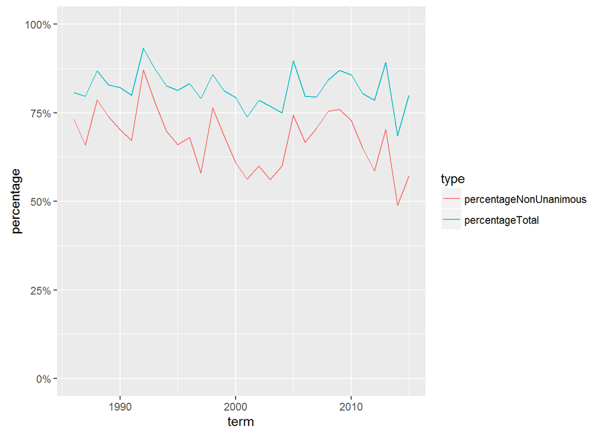

```r
ggplot(jcitation_tidy, aes(term, percentage, color = type)) +
  geom_line() +
  scale_y_continuous(limits = c(0, 1), labels = percent_format())
```

```r
#4
#decision direction = 1 to all
jcitation_ref <- jcitation_all %>%
  distinct(caseIssuesId, .keep_all = TRUE) %>%
  group_by(term) %>%
  summarize(totalNumber = n())

jcitation_ref
```

```
## # A tibble: 223 × 2
##     term totalNumber
##    <int>       <int>
## 1   1791           2
## 2   1792           4
## 3   1793           3
## 4   1794           2
## 5   1795           6
## 6   1796          16
## 7   1797           8
## 8   1798           6
## 9   1799           7
## 10  1800           9
## # ... with 213 more rows
```

```r
jcitation_tidy <- jcitation_all %>%
  distinct(caseIssuesId, .keep_all = TRUE) %>%
  filter(decisionDirection == 1) %>%
  group_by(term) %>%
  summarize(number = n()) %>%
  left_join(jcitation_ref, by = "term") %>%
  mutate(percentage = number / totalNumber)

jcitation_tidy
```

```
## # A tibble: 223 × 4
##     term number totalNumber percentage
##    <int>  <int>       <int>      <dbl>
## 1   1791      1           2  0.5000000
## 2   1792      1           4  0.2500000
## 3   1793      1           3  0.3333333
## 4   1794      1           2  0.5000000
## 5   1795      3           6  0.5000000
## 6   1796      3          16  0.1875000
## 7   1797      4           8  0.5000000
## 8   1798      4           6  0.6666667
## 9   1799      3           7  0.4285714
## 10  1800      5           9  0.5555556
## # ... with 213 more rows
```

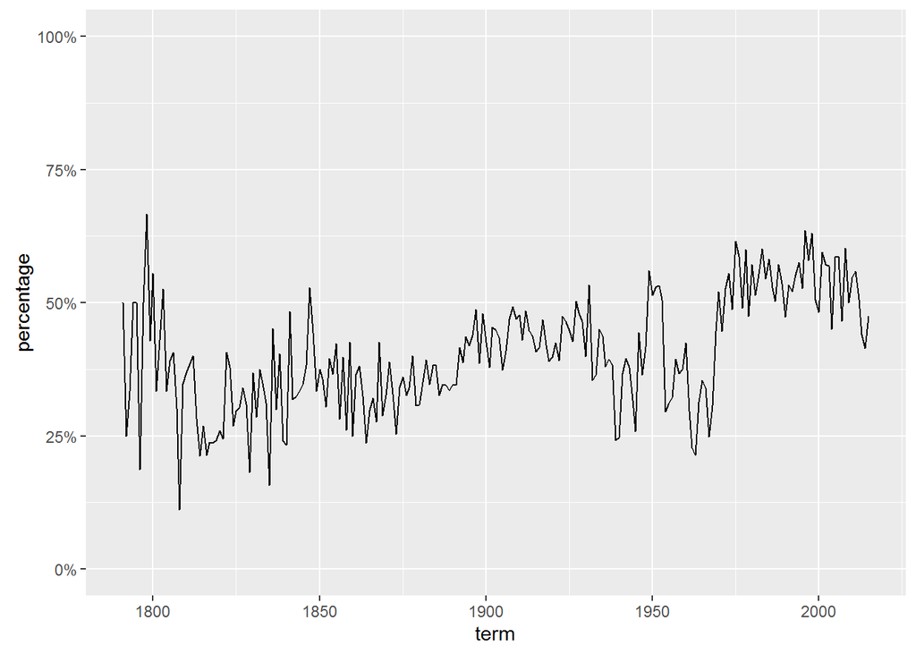

```r
ggplot(jcitation_tidy, aes(term, percentage)) +
  geom_line() +
  scale_y_continuous(limits = c(0, 1), labels = percent_format())
```

```r
#5A
jcitation_chiefref1 <- jcitation_all %>%
  distinct(term, .keep_all = TRUE) %>%
  transmute(term, chief)

jcitation_chiefref1
```

```
## # A tibble: 223 × 2
##     term     chief
##    <int>     <chr>
## 1   1791       Jay
## 2   1792       Jay
## 3   1793       Jay
## 4   1794       Jay
## 5   1795       Jay
## 6   1796  Rutledge
## 7   1797 Ellsworth
## 8   1798 Ellsworth
## 9   1799 Ellsworth
## 10  1800 Ellsworth
## # ... with 213 more rows
```

```r
jcitation_tidy <- jcitation_tidy %>%
  left_join(jcitation_chiefref1, by = "term")

jcitation_tidy
```

```
## # A tibble: 223 × 5
##     term number totalNumber percentage     chief
##    <int>  <int>       <int>      <dbl>     <chr>
## 1   1791      1           2  0.5000000       Jay
## 2   1792      1           4  0.2500000       Jay
## 3   1793      1           3  0.3333333       Jay
## 4   1794      1           2  0.5000000       Jay
## 5   1795      3           6  0.5000000       Jay
## 6   1796      3          16  0.1875000  Rutledge
## 7   1797      4           8  0.5000000 Ellsworth
## 8   1798      4           6  0.6666667 Ellsworth
## 9   1799      3           7  0.4285714 Ellsworth
## 10  1800      5           9  0.5555556 Ellsworth
## # ... with 213 more rows
```

```r
jcitation_chiefref2 <- jcitation_chiefref1 %>%
  mutate(chief = factor(chief)) %>%
  group_by(chief) %>%
  summarize(chiefMean = mean(term), chiefSpan = max(term) - min(term))

jcitation_chiefref2
```

```
## # A tibble: 17 × 3
##        chief chiefMean chiefSpan
##       <fctr>     <dbl>     <int>
## 1     Burger  1977.000        16
## 2      Chase  1868.500         9
## 3  Ellsworth  1798.500         3
## 4     Fuller  1899.500        21
## 5     Hughes  1935.000        10
## 6        Jay  1793.000         4
## 7   Marshall  1819.206        35
## 8  Rehnquist  1995.000        18
## 9    Roberts  2010.000        10
## 10  Rutledge  1796.000         0
## 11     Stone  1943.000         4
## 12      Taft  1925.000         8
## 13     Taney  1850.000        26
## 14    Vinson  1949.000         6
## 15     Waite  1881.000        14
## 16    Warren  1960.500        15
## 17     White  1915.500         9
```

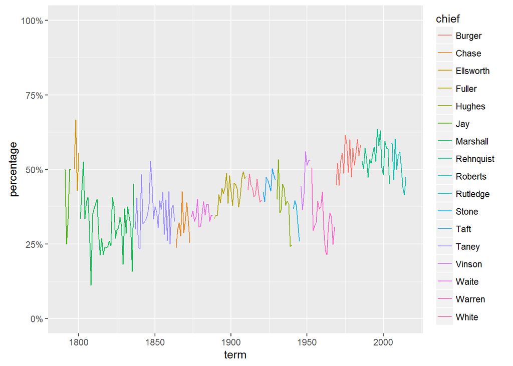

```r
#solution 1
ggplot(jcitation_tidy, aes(term, percentage, color = chief)) +
  geom_line() +
  scale_y_continuous(limits = c(0, 1), labels = percent_format())
```

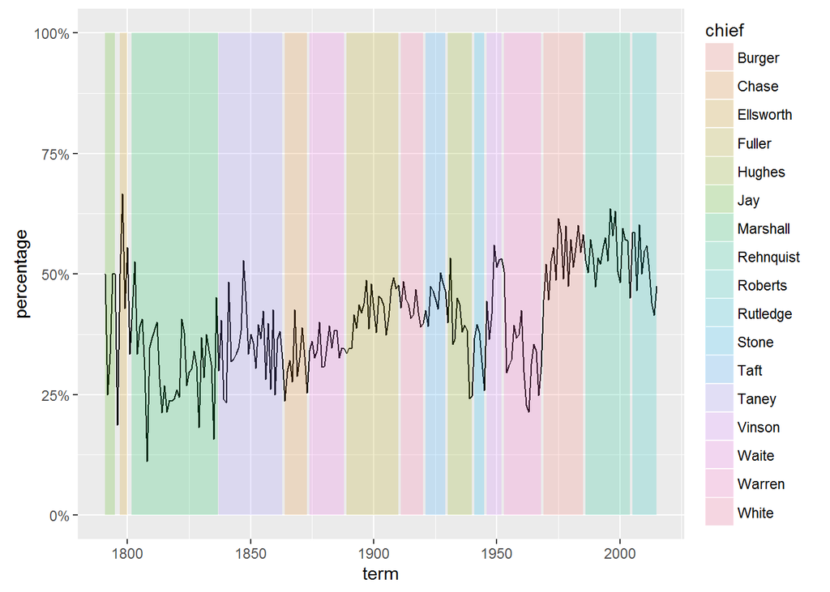

```r
#solution 2
ggplot(jcitation_tidy, aes(term, percentage)) +
  geom_line() +
  geom_tile(data = jcitation_chiefref2, aes(chiefMean, 0.5, fill = chief, width = chiefSpan), alpha = 0.2) +
  scale_y_continuous(limits = c(0, 1), labels = percent_format())
```

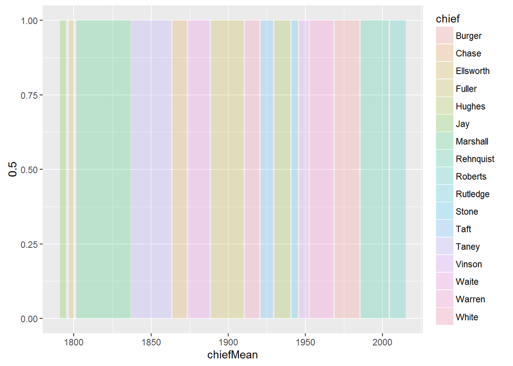

```r
#reference
ggplot(jcitation_chiefref2, aes()) +
  geom_tile(aes(chiefMean, 0.5, fill = chief, width = chiefSpan), alpha = 0.2)
```

```r
df <- data.frame(
  x = rep(c(2, 5, 7, 9, 12)),
  y = rep(c(1), 5),
  z = factor(1:5)
)

df
```

```
##    x y z
## 1  2 1 1
## 2  5 1 2
## 3  7 1 3
## 4  9 1 4
## 5 12 1 5
```

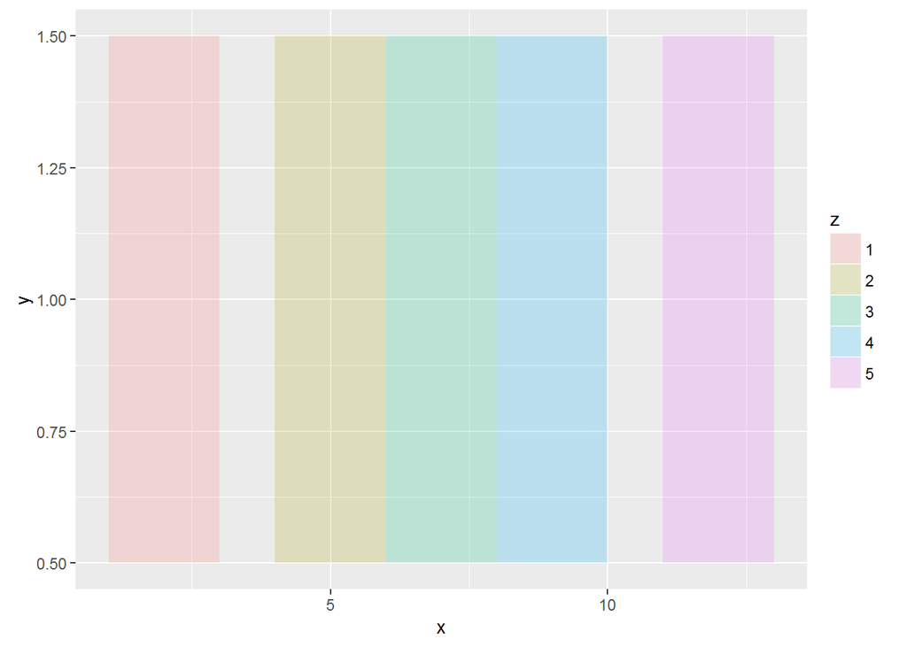

```r
ggplot(df, aes()) +
  geom_tile(aes(x, y, fill = z), alpha = 0.2)
```